# AFDMD-111 Estadística

Lectura de archivos en R

Jorge Toto Hernandez

20/09/2023

# Lectura de archivos en R

`R` puede leer una gran cantidad de archivos incluyendo archivos `.txt`, `.csv`, `.xls`, `.pdf`, etc. Mediante el uso del paquete `tabulizer` se pueden leer tablas que se encuentran en documentos `PDF`. En la siguiente actividad se instalará y cargará el paquete `tabulizer` mediante los comandos:

```r
install.packages("tabulizer", dependencies = TRUE)   # Instala tabulizer
library(tabulizer)                                   # Carga tabulizer
```

Posteriormente se leerá la tabla localizada en el archivo `seccion_calificacionesmsosa247.pdf` que se encuentra en la sección de **archivos** del *Teams* (lo anterior se puede hacer mediante el comando `extract_tables` del tabulizer). Una vez cargada la tabla que se llamará `tablaAlumnos` se realizarán las siguientes actividades:

1.- Graficar `No` contra `Parcial 1`.

```r
library(tabulizer)
library(DT)
tap<-extract_tables("seccion_calificacionesmsosa247.pdf", output = "data.frame")
tap<- tap [[1]]
names(tap)
```

```
[1] "No"        "Matricula" "Nombre"    "Parcial"   "Parcial.1" "Ev."
[7] "Calif."
```

```r
names(tap)<- c("No", "Matricula", "Nombre", "parcial1", "parcial2", "parcial3", "promedio")
head(tap)
```

```
  No Matricula                          Nombre parcial1 parcial2 parcial3
1  1 150300135       ALEJO ALEJANDRO / MIJARES        8        7        7
2  2 150300161       CAN BACAB / HECTOR ARTURO       10        8        8
3  3 150300087      CAN BACAB / SERGIO ANTONIO        7        8        9
4  4 140300086 CERVANTES VILLEGAS / ALAN JAIME        0        0        0
5  5 150300109    CONSTANTINO ISNEROS / MOISES        9        9        6
6  6 150300170          CORONA MERCADO / JESUS        7        6        5
  promedio
1        7
2        9
3        8
4        0
5        8
6        6
```

```r
names(tap)
```

```
[1] "No"        "Matricula" "Nombre"    "parcial1"  "parcial2"  "parcial3"
[7] "promedio"
```

```r
tabladf <- as.data.frame(tap)
datatable(tabladf)
```

|  | No | Matricula | Nombre | parcial1 | parcial2 | parcial3 | promedio |
| --- | --- | --- | --- | --- | --- | --- | --- |
| 1 | 1 | 150300135 | ALEJO ALEJANDRO / MIJARES | 8 | 7 | 7 | 7 |
| 2 | 2 | 150300161 | CAN BACAB / HECTOR ARTURO | 10 | 8 | 8 | 9 |
| 3 | 3 | 150300087 | CAN BACAB / SERGIO ANTONIO | 7 | 8 | 9 | 8 |
| 4 | 4 | 140300086 | CERVANTES VILLEGAS / ALAN JAIME | 0 | 0 | 0 | 0 |
| 5 | 5 | 150300109 | CONSTANTINO ISNEROS / MOISES | 9 | 9 | 6 | 8 |
| 6 | 6 | 150300170 | CORONA MERCADO / JESUS | 7 | 6 | 5 | 6 |
| 7 | 7 | 150300508 | DE LA CRUZ MARTÍNEZ / MAURICIO | 8 | 3 | 10 | 7 |
| 8 | 8 | 150300107 | GALINDO ARROYO / FERNANDO IVAN | 7 | 9 | 6 | 7 |
| 9 | 9 | 150300511 | GARCIA VAZQUEZ / BRANDO | 8 | 8 | 8 | 8 |
| 10 | 10 | 150300123 | GIL GUZMAN / GIOVANY | 8 | 3 | 10 | 7 |

[output cut: 14 more lines]

```r
tap$parcial1
```

```
 [1]  8 10  7  0  9  7  8  7  8  8  5  8  6  8  8  4  8  7  7  5  3  8  6  9
```

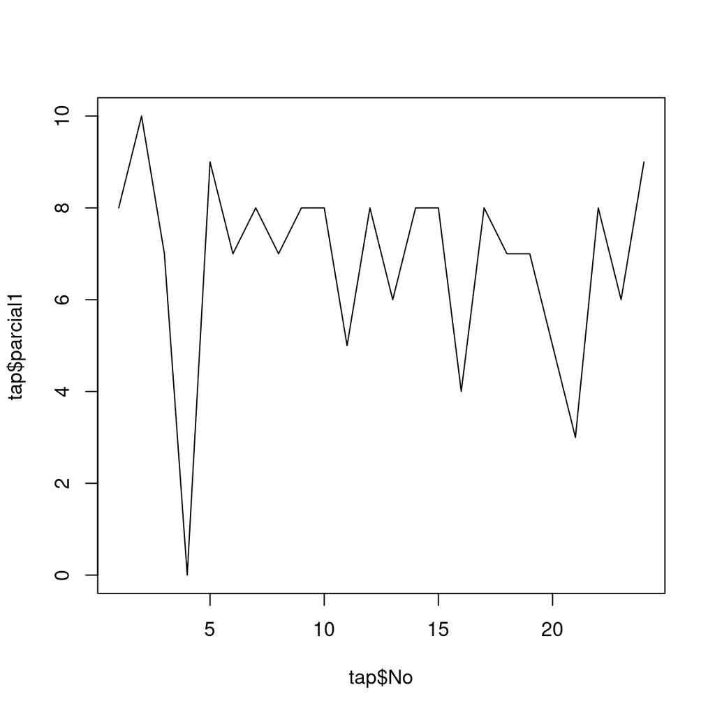

```r
plot(tap$No, tap$parcial1,type = "l")
```

2.- Graficar `No` contra `Parcial 2`.

```r
library(tabulizer)
tap<-extract_tables("seccion_calificacionesmsosa247.pdf", output = "data.frame")
tap<- tap [[1]]
names(tap)
```

```
[1] "No"        "Matricula" "Nombre"    "Parcial"   "Parcial.1" "Ev."
[7] "Calif."
```

```r
names(tap)<- c("No", "Matricula", "Nombre", "parcial1", "parcial2", "parcial3", "promedio")
head(tap)
```

```
  No Matricula                          Nombre parcial1 parcial2 parcial3
1  1 150300135       ALEJO ALEJANDRO / MIJARES        8        7        7
2  2 150300161       CAN BACAB / HECTOR ARTURO       10        8        8
3  3 150300087      CAN BACAB / SERGIO ANTONIO        7        8        9
4  4 140300086 CERVANTES VILLEGAS / ALAN JAIME        0        0        0
5  5 150300109    CONSTANTINO ISNEROS / MOISES        9        9        6
6  6 150300170          CORONA MERCADO / JESUS        7        6        5
  promedio
1        7
2        9
3        8
4        0
5        8
6        6
```

```r
names(tap)
```

```
[1] "No"        "Matricula" "Nombre"    "parcial1"  "parcial2"  "parcial3"
[7] "promedio"
```

```r
tap$parcial2
```

```
 [1] 7 8 8 0 9 6 3 9 8 3 2 9 2 7 8 0 8 9 0 2 2 2 0 8
```

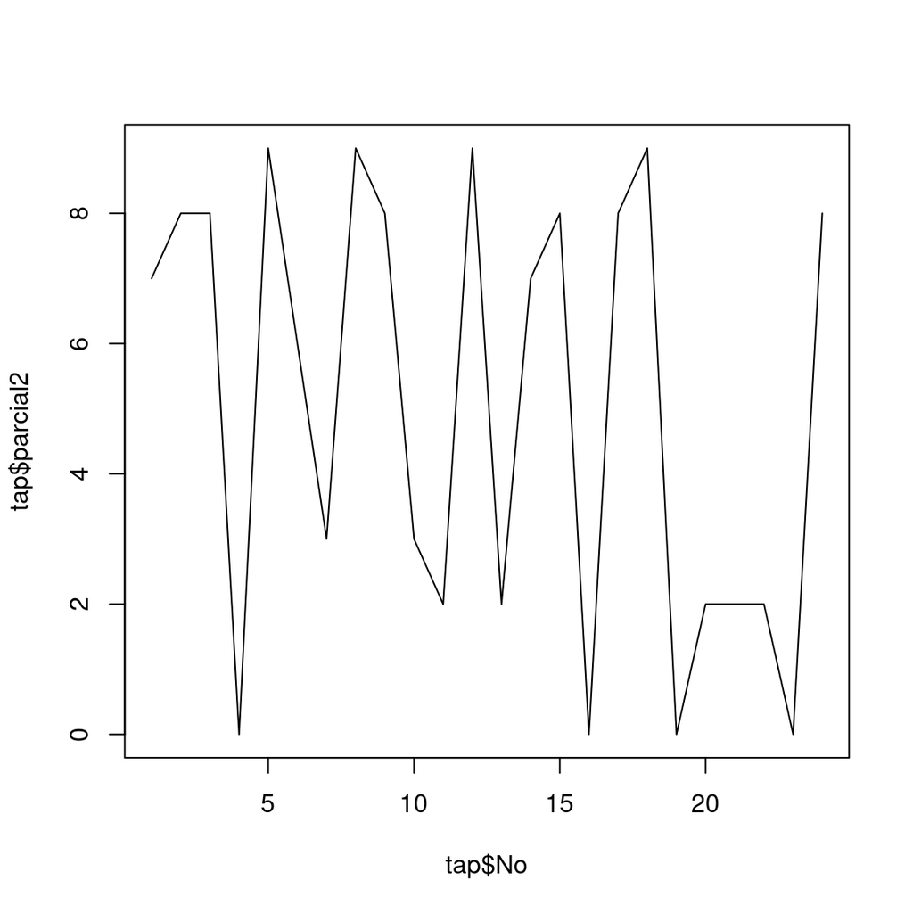

```r
plot(tap$No, tap$parcial2,type = "l")
```

3.- Renombrar `Ev.` a `Parcial 3` (mostrar el `data.frame` resultante).

```r
# Cargar la biblioteca necesaria
library(tabulizer)

# Extraer las tablas del archivo PDF
tap <- extract_tables("seccion_calificacionesmsosa247.pdf", output = "data.frame")
tap <- tap[[1]]

# Renombrar las columnas de la tabla
names(tap) <- c("No", "Matricula", "Nombre", "parcial1", "parcial2", "parcial3", "promedio")

# Mostrar las primeras filas de la tabla
head(tap)
```

```
  No Matricula                          Nombre parcial1 parcial2 parcial3
1  1 150300135       ALEJO ALEJANDRO / MIJARES        8        7        7
2  2 150300161       CAN BACAB / HECTOR ARTURO       10        8        8
3  3 150300087      CAN BACAB / SERGIO ANTONIO        7        8        9
4  4 140300086 CERVANTES VILLEGAS / ALAN JAIME        0        0        0
5  5 150300109    CONSTANTINO ISNEROS / MOISES        9        9        6
6  6 150300170          CORONA MERCADO / JESUS        7        6        5
  promedio
1        7
2        9
3        8
4        0
5        8
6        6
```

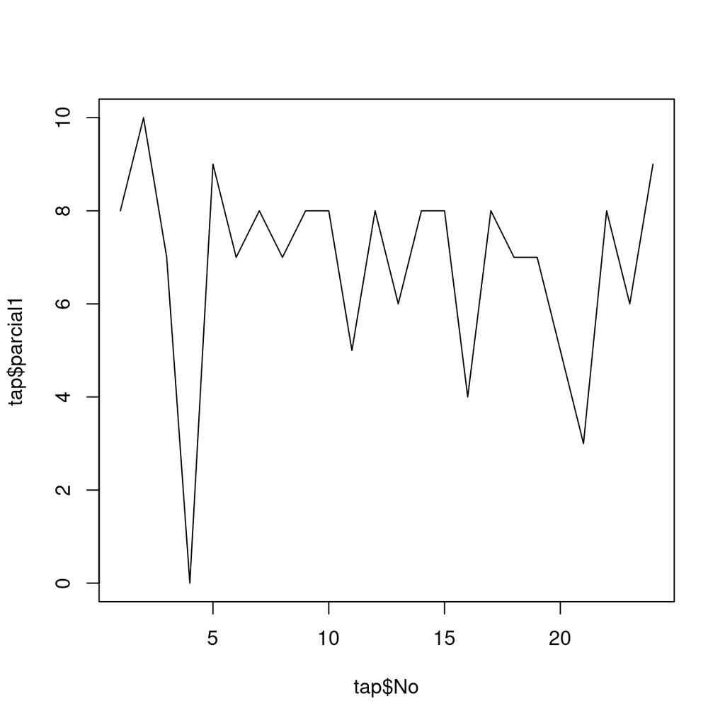

```r
# Graficar No contra Parcial 1
plot(tap$No, tap$parcial1, type = "l")
```

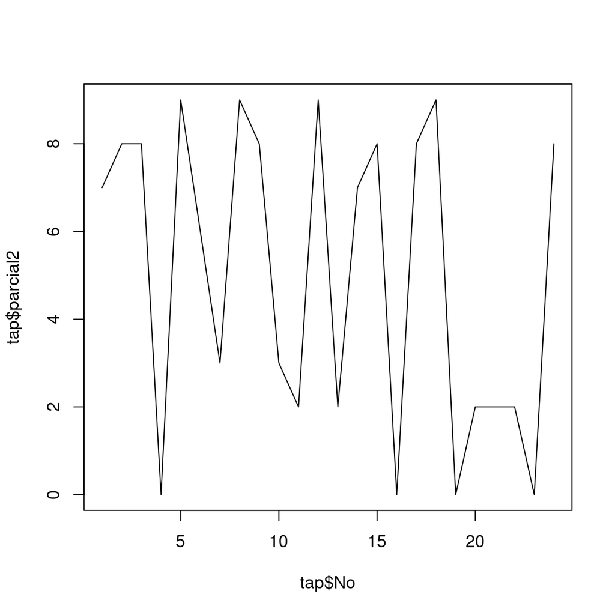

```r
# Graficar No contra Parcial 2
plot(tap$No, tap$parcial2, type = "l")
```

```r
# Renombrar la columna 'Ev.' a 'Parcial 3'
tap$parcial3 <- tap$`Ev.`

# Eliminar la columna 'Ev.'
tap <- tap[, -which(names(tap) == 'Ev.')]

# Mostrar el data.frame resultante
head(tap)
```

```
data frame with 0 columns and 6 rows
```

4.- Graficar `No` contra `Parcial 1`, `Parcial 2`.

```r
# Cargar la biblioteca necesaria
library(tabulizer)

# Extraer las tablas del archivo PDF
tap <- extract_tables("seccion_calificacionesmsosa247.pdf", output = "data.frame")
tap <- tap[[1]]

# Renombrar las columnas de la tabla
names(tap) <- c("No", "Matricula", "Nombre", "parcial1", "parcial2", "parcial3", "promedio")

# Mostrar las primeras filas de la tabla
head(tap)
```

```
  No Matricula                          Nombre parcial1 parcial2 parcial3
1  1 150300135       ALEJO ALEJANDRO / MIJARES        8        7        7
2  2 150300161       CAN BACAB / HECTOR ARTURO       10        8        8
3  3 150300087      CAN BACAB / SERGIO ANTONIO        7        8        9
4  4 140300086 CERVANTES VILLEGAS / ALAN JAIME        0        0        0
5  5 150300109    CONSTANTINO ISNEROS / MOISES        9        9        6
6  6 150300170          CORONA MERCADO / JESUS        7        6        5
  promedio
1        7
2        9
3        8
4        0
5        8
6        6
```

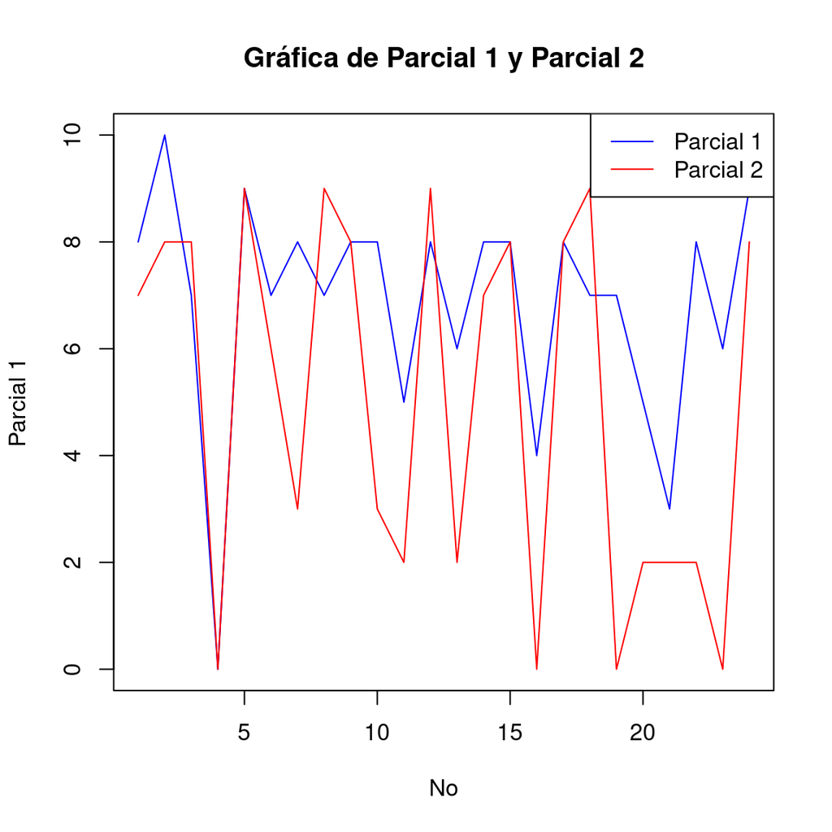

```r
# Graficar No contra Parcial 1
plot(tap$No, tap$parcial1, type = "l", col = "blue", xlab = "No", ylab = "Parcial 1")

# Agregar la línea de Parcial 2 a la misma gráfica
lines(tap$No, tap$parcial2, type = "l", col = "red")

# Agregar una leyenda
legend("topright", legend = c("Parcial 1", "Parcial 2"), col = c("blue", "red"), lty = 1)

# Título de la gráfica
title("Gráfica de Parcial 1 y Parcial 2")
```

5.- ¿Cuál es la media de las calificaciones finales? ¿Quién obtuvo la calificación más baja? ¿Quién obtuvo el mejor promedio? (anexar el código que lo calcula).

```r
# Cargar la biblioteca necesaria
library(tabulizer)

# Extraer las tablas del archivo PDF
tap <- extract_tables("seccion_calificacionesmsosa247.pdf", output = "data.frame")
tap <- tap[[1]]

# Renombrar las columnas de la tabla
names(tap) <- c("No", "Matricula", "Nombre", "parcial1", "parcial2", "parcial3", "promedio")

# Calcular la media de las calificaciones finales
media_final <- mean(tap$promedio)
cat("La MEDIA de las calificaciones finales es:", media_final, "\n")
```

```
La MEDIA de las calificaciones finales es: 5.958333
```

```r
# Encontrar estudiantes con la calificación más baja
calificacion_minima <- min(tap$promedio)
estudiantes_minimos <- tap[tap$promedio == calificacion_minima, "Nombre"]
cat("Los estudiantes con la calificación MAS BAJA son:", paste(estudiantes_minimos, collapse = ", "), "con una calificación de", calificacion_minima, "\n")
```

```
Los estudiantes con la calificación MAS BAJA son: CERVANTES VILLEGAS / ALAN JAIME, PAT MAY / JOHANES BENJAMIN, SALGADO GONZALEZ / ADAN OMAR, SÁNCHEZ PARTIDA / ALAN MISSAEL con una calificación de 0
```

```r
# Encontrar estudiantes con el mejor promedio
calificacion_maxima <- max(tap$promedio)
estudiantes_maximos <- tap[tap$promedio == calificacion_maxima, "Nombre"]
cat("Los estudiantes con el MEJOR PROMEDIO son:", paste(estudiantes_maximos, collapse = ", "), "con una calificación de", calificacion_maxima, "\n")
```

```
Los estudiantes con el MEJOR PROMEDIO son: CAN BACAB / HECTOR ARTURO, HERNÁNDEZ VALENCIA / ESTEBAN RAMÓN con una calificación de 9
```

6.- Cree una nueva columna llamada `promedio` (esto lo puede hacer con `mutate` del paquete `dplyr`) y compárela con la columna `Calif.` (¿Qué se puede observar?).

```r
# Cargar las bibliotecas necesarias
library(tabulizer)
library(dplyr)

# Extraer las tablas del archivo PDF
tap <- extract_tables("seccion_calificacionesmsosa247.pdf", output = "data.frame")
tap <- tap[[1]]

# Renombrar las columnas de la tabla
names(tap) <- c("No", "Matricula", "Nombre", "parcial1", "parcial2", "parcial3", "Calif.")

# Convertir la columna "Calif." a numérica (si es necesario)
tap$Calif. <- as.numeric(tap$Calif.)

# Crear una nueva columna llamada "promedio" calculada como el promedio de las columnas de parciales
tap <- tap %>%
  mutate(promedio = (parcial1 + parcial2 + parcial3) / 3)

# Comparar la columna "promedio" con la columna "Calif."
comparison <- tap %>%
  select(promedio, Calif.)

# Imprimir los primeros registros de la comparación
head(comparison)
```

```
  promedio Calif.
1 7.333333      7
2 8.666667      9
3 8.000000      8
4 0.000000      0
5 8.000000      8
6 6.000000      6
```

Se observa que en “promedio” las calificaciones nos dan decimales y si por ejemplo el promedio es 7.33333 en la “calificacion” se cerrara como 7 pero si el “promedio” es 8.6666 la “calificacion” se cerrara en 9.

Posteriormente lea el archivo `it0103_2016_01.csv` (lo puede hacer mediante el comando `read.csv()`) el cual es una versión `sucia` del archivo anterior y replique cada uno de los puntos de arriba (sí es necesario modifique el data.frame resultante).

```r
excel <- read.csv("it0103_2016_01.csv")
exceldf <- as.data.frame(excel)
datatable(exceldf)
```

|  | No | Matricula | Nombre | Calif. | Examen | Calificacion |
| --- | --- | --- | --- | --- | --- | --- |
| 1 | 1 | 150300135 | ALEJO ALEJANDRO / MIJARES | 7 | Parcial1 | 8 |
| 2 | 2 | 150300161 | CAN BACAB / HECTOR ARTURO | 9 | Parcial1 | 10 |
| 3 | 3 | 150300087 | CAN BACAB / SERGIO ANTONIO | 8 | Parcial1 | 7 |
| 4 | 4 | 140300086 | CERVANTES VILLEGAS / ALAN JAIME | 0 | Parcial1 | 0 |
| 5 | 5 | 150300109 | CONSTANTINO ISNEROS / MOISES | 8 | Parcial1 | 9 |
| 6 | 6 | 150300170 | CORONA MERCADO / JESUS | 6 | Parcial1 | 7 |
| 7 | 7 | 150300508 | DE LA CRUZ MARTÍNEZ / MAURICIO | 7 | Parcial1 | 8 |
| 8 | 8 | 150300107 | GALINDO ARROYO / FERNANDO IVAN | 7 | Parcial1 | 7 |
| 9 | 9 | 150300511 | GARCIA VAZQUEZ / BRANDO | 8 | Parcial1 | 8 |
| 10 | 10 | 150300123 | GIL GUZMAN / GIOVANY | 7 | Parcial1 | 8 |

[output cut: 62 more lines]

```r
excNo <- exceldf$No[1:24]
excMatri <- exceldf$Matricula[1:24]
excNom <- exceldf$Nombre[1:24]
excPar1 <- exceldf$Calificacion[1:24]
excPar2 <- exceldf$Calificacion[25:48]
excPar3 <- exceldf$Calificacion[49:72]
excCal <- exceldf$Calif.[1:24]
```

1. Graficar No contra Parcial 1.

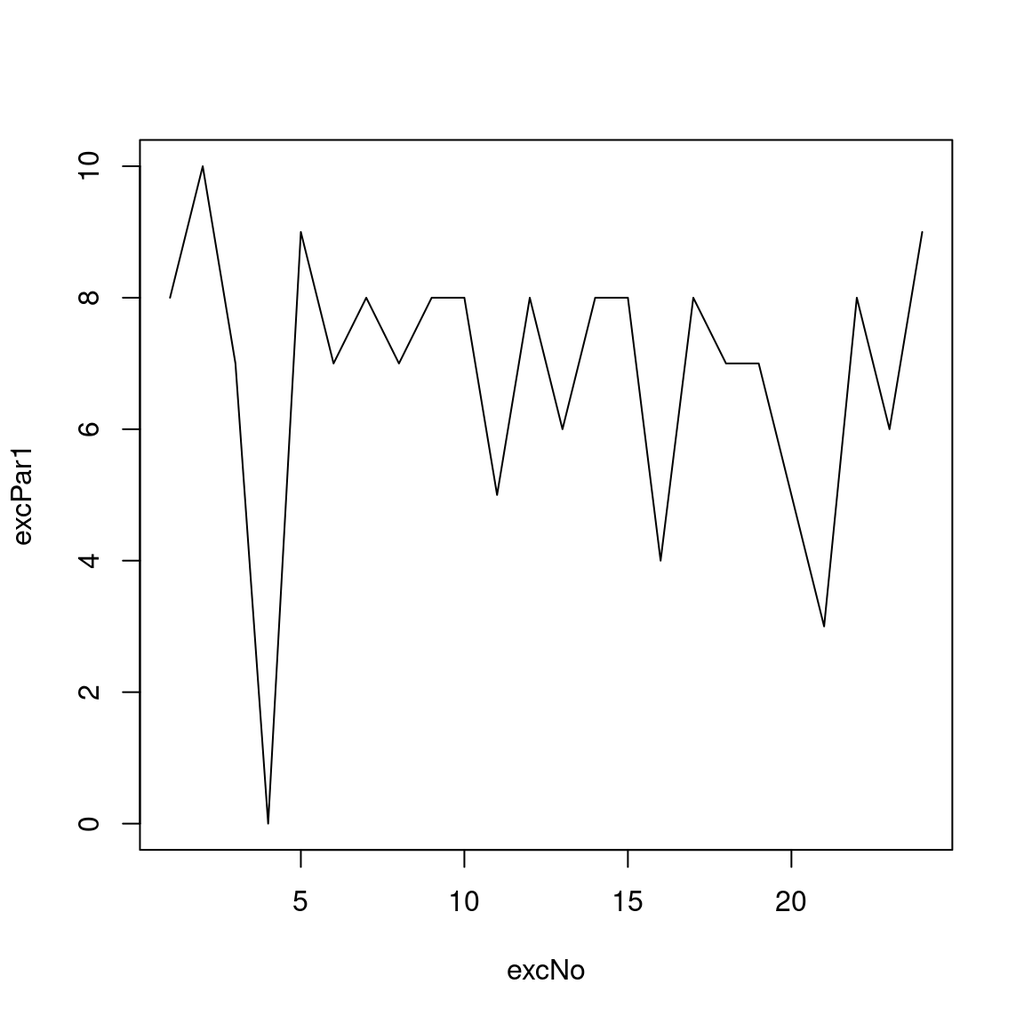

```r
plot(excNo, excPar1, type = "l")
```

2. Graficar No contra Parcial 2.

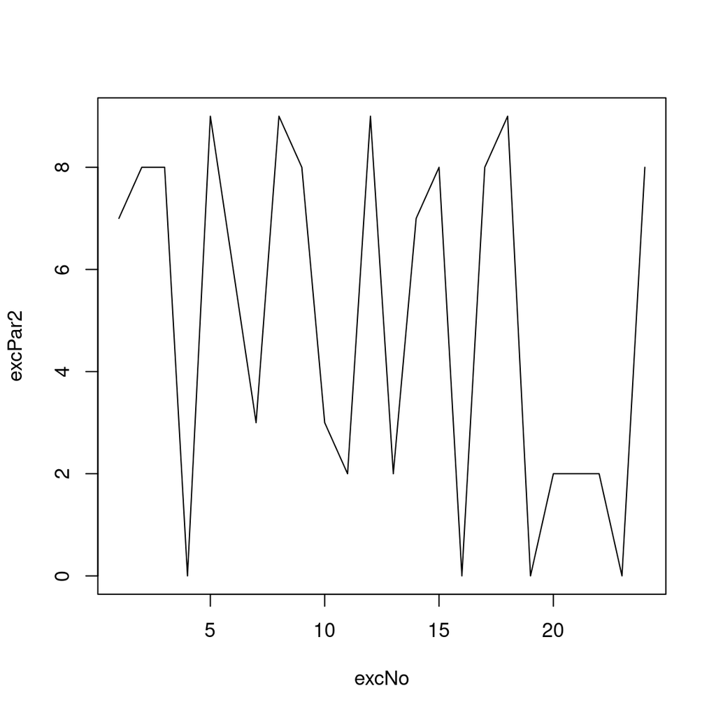

```r
plot(excNo, excPar2, type = "l")
```

3. Renombrar Ev. a Parcial 3(Mostrar el data.frame resultante)

```r
exceldf <- data.frame(
  No = excNo,
  Matricula = excMatri,
  Nombre = excNom,
  Parcial1 = excPar1,
  Parcial2 = excPar2,
  Parcial3 = excPar3,
  Calif. = excCal
  )
  datatable(exceldf)
```

|  | No | Matricula | Nombre | Parcial1 | Parcial2 | Parcial3 | Calif. |
| --- | --- | --- | --- | --- | --- | --- | --- |
| 1 | 1 | 150300135 | ALEJO ALEJANDRO / MIJARES | 8 | 7 | 7 | 7 |
| 2 | 2 | 150300161 | CAN BACAB / HECTOR ARTURO | 10 | 8 | 8 | 9 |
| 3 | 3 | 150300087 | CAN BACAB / SERGIO ANTONIO | 7 | 8 | 9 | 8 |
| 4 | 4 | 140300086 | CERVANTES VILLEGAS / ALAN JAIME | 0 | 0 | 0 | 0 |
| 5 | 5 | 150300109 | CONSTANTINO ISNEROS / MOISES | 9 | 9 | 6 | 8 |
| 6 | 6 | 150300170 | CORONA MERCADO / JESUS | 7 | 6 | 5 | 6 |
| 7 | 7 | 150300508 | DE LA CRUZ MARTÍNEZ / MAURICIO | 8 | 3 | 10 | 7 |
| 8 | 8 | 150300107 | GALINDO ARROYO / FERNANDO IVAN | 7 | 9 | 6 | 7 |
| 9 | 9 | 150300511 | GARCIA VAZQUEZ / BRANDO | 8 | 8 | 8 | 8 |
| 10 | 10 | 150300123 | GIL GUZMAN / GIOVANY | 8 | 3 | 10 | 7 |

[output cut: 14 more lines]

4. Graficar No contra Parcial 1 y Parcial 2.

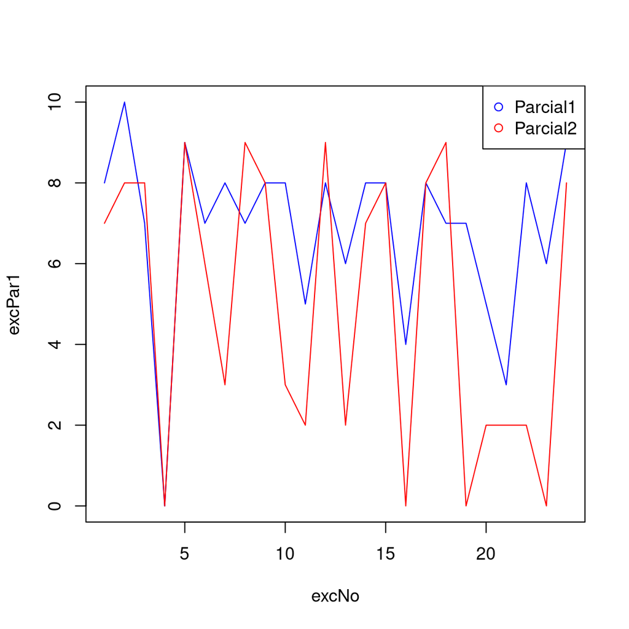

```r
plot(excNo, excPar1, type = "l", col = "blue")
lines(excNo, excPar2, type = "l", col = "red")
legend("topright", legend = c("Parcial1", "Parcial2"), col = c("blue", "red"), pch = c(1, 1))
```